# Between-Sample (Beta) Diversity of Microbes along a Salinity Gradient

Mar Schmidt

April 17, 2025

# Goals

1. Load in phyloseq data with rooted tree & colors and functions.
2. Evaluate sequencing depth and remove samples, if needed.
3. Normalize the read counts between samples.
4. Calculate community **dis**similarities. Numbers between 0 and 1. If 0, completely similar versus if they are 1, then they’re completely dissimilar.
   1. **Sorensen**: Shared Species as a binary value: Abundance-unweighted
   2. **Bray-Curtis**: Shared Abundant species: Abundance-weighted
   3. **(Abundance-)Weighted UNIFRAC**: Consider Abundant Species and where they fall on the tree
5. Run statistics with functions from the vegan R package:
   1. PERMANOVA with `adonis2()`.
   2. betadispR with `betadisper()` and `permutest()`.
6. Visualize the community data with two unconstrained Ordinations:
   1. **PCoA**: Linear Method. Eigenvalue = how much variation is explained by each axis. Choose to view axis 1, 2, 3, etc. and plot them together.
   2. **NMDS**: Non-linear. Smush multiple Dimensions into 2 or 3 axes. Need to report Stress value (ideally <0.15).
1. We will need the `phytree_preprocessed_physeq.RData`, which includes a rooted tree (ideally within the archaea!) that we created in `analysis/04B_Phylogenetic_Tree_Inspection.Rmd`.

## Outputs

*This is an exciting analysis!!! We get to answer another one of our scientific questions!*

1. Calculated beta-diversity dissimilarity measures (*e.g.* Sorensen, Bray-Curtis, abundance-unweighted and -weighted UniFrac) across every sample.
2. Ordination figures (*i.e.,* PCoA/NMDS) to include in the scientific paper that visualize the data as it relates to the scientific question.
3. Statistical tests (*i.e.,* PERMANOVA & betadisper) conveying the measured and quantified changes and patterns in biodiversity.

# Scientific Question

How does microbial composition change across a salinity gradient?

- *Null Hypothesis:* Microbial composition (*e.g.* Sorensen, Bray-Curtis, abundance-unweighted and -weighted UniFrac) does not change across a salinity gradient.
- *Alternative #1 Hypothesis:* Microbial composition (*e.g.* Sorensen, Bray-Curtis, abundance-unweighted and -weighted UniFrac) will become more dissimilar as salt concentration lowers. There is an inverse relationship between richness and salinity.
- *Altnerative #2 Hypothesis*: Dominant members of the microbial community (*e.g.* Bray-Curtis, abundance-weighted UniFrac) are unique in freshwater compared to salt water.

INTERPRETATION #1: What is your scientific question and hypotheses? Do they relate to abundance? Presence/absence? Phylogeny?

# Set up

## Timing of this script

```r
# What time did we start running this script?
start_time <- Sys.time()
```

## Set the seed

```r
set.seed(238428)
```

## Load Packages, colors & functions

```r
pacman::p_load(tidyverse, devtools, phyloseq, patchwork, vegan,
               install = FALSE)

# Load Colors
source("code/colors.R")

# Load functions
source("code/functions.R")
```

# 1. Load in the data

```r
# load phyloseq object
load("data/04_PhylogeneticTree/phytree_preprocessed_physeqs.RData")
archaeal_rooted_physeq
```

```
## phyloseq-class experiment-level object
## otu_table()   OTU Table:         [ 2605 taxa and 89 samples ]
## sample_data() Sample Data:       [ 89 samples by 43 sample variables ]
## tax_table()   Taxonomy Table:    [ 2605 taxa by 9 taxonomic ranks ]
## phy_tree()    Phylogenetic Tree: [ 2605 tips and 2604 internal nodes ]
```

```r
# Intuition check on seq depth
min(sample_sums(archaeal_rooted_physeq))
```

```
## [1] 1576
```

## Remove outlier sample

Through the biodiversity and also in class, we saw that there was a clear outlier in the data named `20210615-MA-ABB2F`. This sample also appeared to be the shallowest sample in terms of sequencing and also an outlier in terms of biodiversity. So, we will remove it for the samples here.

```r
archaeal_rooted_physeq <-
  archaeal_rooted_physeq %>%
  subset_samples(names != "20210615-MA-ABB2F") %>%
  # And remove any ASVs unique to this sample, just in case.
  prune_taxa(taxa_sums(.) > 0, .)

# Check that we now have 88 samples
archaeal_rooted_physeq
```

```
## phyloseq-class experiment-level object
## otu_table()   OTU Table:         [ 2535 taxa and 88 samples ]
## sample_data() Sample Data:       [ 88 samples by 43 sample variables ]
## tax_table()   Taxonomy Table:    [ 2535 taxa by 9 taxonomic ranks ]
## phy_tree()    Phylogenetic Tree: [ 2535 tips and 2534 internal nodes ]
```

```r
# Create Metadata_df
metadata_df <-
  archaeal_rooted_physeq %>%
  sample_data() %>%
  data.frame()
```

# Normalizing the Read Depth

## 2. Explore the Raw Read Counts

```r
# calculate read counts per sample
raw_TotalSeqs_df <-
  archaeal_rooted_physeq %>%
  # Calculate the total number of sequences/reads
  sample_sums() %>%
  data.frame()

# Take a look
head(raw_TotalSeqs_df)
```

```
##                      .
## 20210602-MA-ABB1F 3430
## 20210602-MA-ABB1P 2603
## 20210602-MA-ABB1W 4784
## 20210602-MA-ABS1F 3182
## 20210602-MA-ABS1P 3190
## 20210602-MA-ABS1W 4053
```

```r
# Rename the column
colnames(raw_TotalSeqs_df)[1] <- "TotalSeqs"

# add a new column of num_ASVs (RAW, non-noramlized # ASVs)
raw_TotalSeqsASVs_df <-
  raw_TotalSeqs_df %>%
  mutate(num_ASVs = colSums(otu_table(archaeal_rooted_physeq) > 1))

#View(raw_TotalSeqsASVs_df)

# Plot histogram of seq depth
rawSeq_histogram <-
  raw_TotalSeqsASVs_df %>%
  ggplot(aes(x = TotalSeqs)) +
  geom_histogram(bins = 50) +
  scale_x_continuous(limits = c(0, 7500)) +
  labs(title = "Raw Seq Depth Histogram") +
  theme_bw()

# Plot Seq Depth versus num_ASVs
rawSeq_vs_numASV_plot <-
  raw_TotalSeqsASVs_df %>%
  ggplot(aes(x = num_ASVs, y = TotalSeqs)) +
  geom_point() +
  scale_y_continuous(limits = c(0, 7500)) +
  geom_smooth(method = "lm") +
  labs(title = "Seq Depth vs # ASVs") +
  theme_bw()

# is it significant?
summary(lm(TotalSeqs ~ num_ASVs, data = raw_TotalSeqsASVs_df))
```

```
##
## Call:
## lm(formula = TotalSeqs ~ num_ASVs, data = raw_TotalSeqsASVs_df)
##
## Residuals:
##      Min       1Q   Median       3Q      Max
## -1908.55  -572.45   -27.85   518.55  2167.24
##
## Coefficients:
##             Estimate Std. Error t value Pr(>|t|)
## (Intercept)  1655.73     577.61   2.867  0.00522 **
## num_ASVs       18.66       4.27   4.370 3.46e-05 ***
## ---
## Signif. codes:  0 '***' 0.001 '**' 0.01 '*' 0.05 '.' 0.1 ' ' 1
##
## Residual standard error: 892.8 on 86 degrees of freedom
## Multiple R-squared:  0.1817, Adjusted R-squared:  0.1722
## F-statistic:  19.1 on 1 and 86 DF,  p-value: 3.457e-05
```

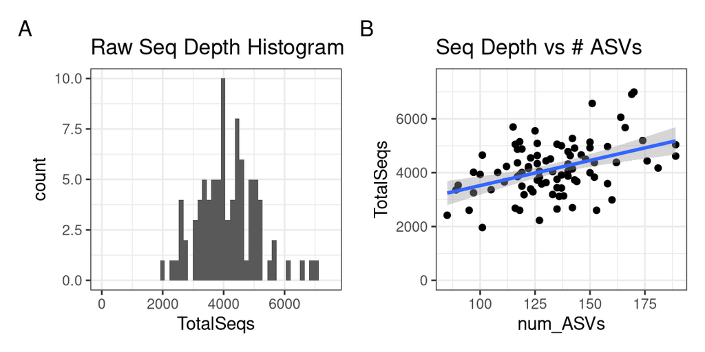

```r
# Put the two plots together.
rawSeq_histogram + rawSeq_vs_numASV_plot +
  plot_annotation(tag_levels = "A")
```

INTERPRETATION #2: Evaluating the above plots, what did you scale the read counts to in your dataset? Why did you choose that number? Do you think it is sufficient to perform a beta-diversity analysis and accurately compare your data to one another?

# 3. Scale Read Counts

```r
min(sample_sums(archaeal_rooted_physeq))
```

```
## [1] 1962
```

```r
# Scale the reads
scaled_physeq <-
  archaeal_rooted_physeq %>%
  scale_reads(round = "matround")

# Look at it
scaled_physeq
```

```
## phyloseq-class experiment-level object
## otu_table()   OTU Table:         [ 2535 taxa and 88 samples ]
## sample_data() Sample Data:       [ 88 samples by 43 sample variables ]
## tax_table()   Taxonomy Table:    [ 2535 taxa by 9 taxonomic ranks ]
## phy_tree()    Phylogenetic Tree: [ 2535 tips and 2534 internal nodes ]
```

```r
# Look at it more!
#View(data.frame(otu_table(archaeal_rooted_physeq)))
#View(data.frame(otu_table(scaled_physeq)))

# Confirm seq read depth of scaled_physeq
scaled_TotalSeqs_df <-
  scaled_physeq %>%
  sample_sums() %>%
  data.frame()

colnames(scaled_TotalSeqs_df)[1] <- "TotalSeqs"

# add a new column of num_ASVs (RAW, non-noramlized # ASVs)
scaled_TotalSeqsASVs_df <-
  scaled_TotalSeqs_df %>%
  mutate(num_ASVs = colSums(otu_table(scaled_physeq) > 1))

# Plot it!
scaledSeq_histogram <-
  scaled_TotalSeqs_df %>%
  ggplot(aes(x = TotalSeqs)) +
  geom_histogram(bins = 50) +
  labs(title = "Scaled Seq Depth Histogram") +
  scale_x_continuous(limits = c(0, 7500)) +
  theme_bw()

# Scaling always gives us a range!
# MInimum sequences
min(scaled_TotalSeqs_df$TotalSeqs)
```

```
## [1] 1942
```

```r
# Total Range
range(scaled_TotalSeqs_df)
```

```
## [1] 1942 1990
```

```r
# How many is that range?
range_seqs <- (max(scaled_TotalSeqs_df$TotalSeqs) - min(scaled_TotalSeqs_df$TotalSeqs))
range_seqs
```

```
## [1] 48
```

```r
# And in terms of percent?
range_seqs/max(scaled_TotalSeqs_df$TotalSeqs)
```

```
## [1] 0.0241206
```

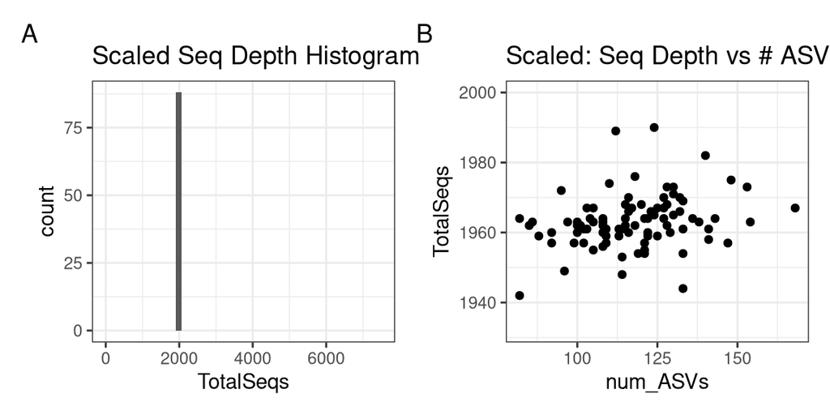

```r
#View(scaled_TotalSeqs_df)

# Set the axis min and max for the next plot
max_y <- max(scaled_TotalSeqs_df$TotalSeqs) + 10
min_y <- min(scaled_TotalSeqs_df$TotalSeqs) - 10

# Now, draw the plot
scaledSeq_vs_numASV_plot <-
  scaled_TotalSeqsASVs_df %>%
  ggplot(aes(x = num_ASVs, y = TotalSeqs)) +
  geom_point() +
  scale_y_continuous(limits = c(min_y, max_y)) +
  #geom_smooth(method = "lm") +
  theme_bw() +
  labs(title = "Scaled: Seq Depth vs # ASVs")

# Put the two plots together.
scaledSeq_histogram + scaledSeq_vs_numASV_plot +
  plot_annotation(tag_levels = "A")
```

INTERPRETATION #3: Evaluate the scaled read count plots above. Are the total number of sequences across all of your samples in the same general range? What is the minimum and maximum (i.e., the range) of the sequencing depth? How was the relationship with the number of ASVs modified after scaling the read counts?

# Beta Diversity: Dissimilarity Metrics in Microbial Ecology

## Similarity versus Dissimilarity

In microbial ecology, **beta diversity** refers to the **similiarty or dissimilarity**, which represent the unique-ness between two microbial community samples. (Dis)similarity values range from **0 to 1**:

- **Similarity**: Values close to 1 = communities are the same whereas 0 = completely different communities.
- **Dissimilarity**: Values close to 1 = the communities are unique whereas 0 refers to identical communities.

Most ecological studies and ordination plots use **dissimilarity**. For some metrics like Jaccard and Sorensen, you’ll see formulas written as similarity—but it’s easy to convert them.

Different dissimilarity metrics emphasize different aspects of community differences—such as presence/absence, abundance, or evolutionary relatedness (phylogeny). Choosing the right metric depends on your scientific question! It is up to us as data analysts to run each of these dissimilarities on our microbial community samples. This multi-faceted approach will provide a multifaceted view of our microbial communities of interest.

### Why do most ecological studies use **dissimilarity**?

In short: dissimilarity tells us how different things are—just like distance. That’s why it’s the default for ordination, clustering, and most ecological statistics. Most ecological studies and ordination plots use dissimilarity (instead of similarity) for several practical and conceptual reasons:

1. **Distance = Difference is an intuitive interpretation**: In ecological studies, dissimilarity is more commonly used than similarity because it aligns more naturally with how we interpret spatial relationships and ecological gradients. Dissimilarity measures provide a sense of how far apart two communities are in terms of their species composition, abundance, or evolutionary history (*remember, this depends on our dissimilarity metric!*). This framing is intuitive: the more dissimilar two samples are, the greater the distance between them in ecological space.
2. **Ordination methods are built for distances:** Ordination methods such as **Principal Coordinates Analysis (PCoA)** and **Non-metric Multidimensional Scaling (NMDS)** (*more on this below!*) are specifically designed to work with dissimilarity (or distance) matrices. These techniques use dissimilarity values to position samples in a low-dimensional space where the distance between points reflects how different the communities are. This makes it easy to visualize clustering patterns, gradients, or dispersions among samples. If we were to use similarity instead, we’d have to invert or transform the values to interpret them spatially, which can introduce confusion.
3. **Avoids ambiguity in similiarty scaling**: Using dissimilarity also avoids ambiguity in scaling. While similarity values like 0.8 or 0.9 may indicate that two samples are quite alike, they don’t translate as directly to spatial relationships. In contrast, a dissimilarity of 0.2 is straightforward—it tells us that the communities are relatively close, and a value of 0.8 signals they are far apart. This linear and spatial logic makes dissimilarity the more practical choice for ecological analyses.
4. **Consistency across fields and tools**: Moreover, dissimilarity metrics are the standard input for most statistical and visualization tools used in microbial ecology, including software packages like QIIME2, phyloseq, and vegan in R. These tools assume you’re comparing how different communities are from one another, not how similar they are. As a result, dissimilarity-based approaches are not only easier to interpret but also more compatible with existing methods and workflows.
5. **Easier to identify ecological gradients**: Therefore, dissimilarity measures dominate ecological studies and visualizations because they match how we interpret differences in space, work seamlessly with ordination and clustering methods, and provide a clear, consistent framework for understanding ecological patterns.

## Common dissimilarity measures

### How do I choose the right dissimilarity metric?

| Scientific Question | Recommended Metric(s) |
| --- | --- |
| Do the two environments share the same microbes, regardless of abundance? | Jaccard, Sorensen |
| How does abundance differ between communities? | Bray-Curtis |
| Are there differences in the evolutionary history of microbes between samples? | UniFrac (unweighted or weighted) |
| Do dominant, evolutionarily distinct microbes vary in abundance? | Weighted UniFrac |

Choosing the right dissimilarity measure starts with understanding what aspect of community difference you’re trying to capture. If you’re asking whether two environments simply contain the same taxa—regardless of how abundant those taxa are—then presence/absence-based measures like **Jaccard** or **Sorensen-Dice** are appropriate. These metrics are particularly useful when working with rarefied data, or when you’re more concerned with community membership than abundance.

If you’re interested in how **abundant** different taxa are across communities—especially if dominant taxa may be ecologically important—then an abundance-based metric like **Bray-Curtis** is a better choice. Bray-Curtis emphasizes changes in relative abundance and is sensitive to shifts in dominant taxa, making it useful for studying processes like competitive exclusion or resource-driven community turnover.

When your data include **phylogenetic information**—for example, from 16S rRNA gene amplicon sequencing—you may want to use **UniFrac** metrics. **Unweighted UniFrac** is good for detecting evolutionary differences based on presence/absence (i.e., whether the communities harbor different lineages), while **Weighted UniFrac** incorporates both **phylogeny and abundance**, allowing you to explore whether communities differ in their evolutionary makeup **and** in the dominance of certain lineages. These are especially useful when you care about deep evolutionary divergence or when function may correlate with phylogeny.

Practical considerations also matter. For example, UniFrac requires a phylogenetic tree, which takes time and computation to build; Bray-Curtis and Jaccard don’t. Some metrics are also more sensitive to sampling depth and rare taxa, so normalization or rarefaction methods may be necessary before analysis.

In short, let your **ecological question** guide your metric choice: use **presence/absence** metrics to assess “who’s there,” **abundance-based** metrics to examine “how much is there,” and **phylogenetic** metrics to explore “how evolutionarily different are these communities.” Often, using **multiple metrics in parallel** can help reveal different facets of the data and strengthen your ecological interpretations.

These dissimilarity measures are foundational tools in microbial ecology and are often visualized using **ordination methods** (e.g., PCoA, NMDS) to interpret community shifts across environments, treatments, or gradients.

| Metric | Type | Similarity Formula | Dissimilarity Formula | Uses Abundance | Uses Phylogeny |
| --- | --- | --- | --- | --- | --- |
| Jaccard | Presence/absence | $\frac{A}{A+B+C}$ | $\frac{B+C}{A+B+C}$ | ❌ | ❌ |
| Sorensen-Dice | Presence/absence | $\frac{2A}{2A+B+C}$ | $\frac{B+C}{2A+B+C}$ | ❌ | ❌ |
| Bray-Curtis | Abundance-based | — | $\frac{\sum \|a_i - b_i\|}{\sum (a_i + b_i)}$ | ✅ | ❌ |
| Unweighted UniFrac | Phylogenetic + presence/absence | — | $\frac{\text{unique branch}}{\text{total branch}}$ | ❌ | ✅ |
| Weighted UniFrac | Phylogenetic + abundance-based | — | $\frac{\text{weighted unique branch}}{\text{total branch}}$ | ✅ | ✅ |

## Five Types of Dissimilarities

### A. Jaccard Dissimilarity

- **Type:** Presence/absence
- **Formula:**
  $$D_J = \frac{B + C}{A + B + C}$$
  Where:
  - *A* = number of taxa shared by both samples
  - *B* = taxa unique to sample 1
  - *C* = taxa unique to sample 2
- **Interpretation:** Measures dissimilarity in community **membership**—i.e., how many taxa are **not shared** between the samples.
- **Ecological question:** *How unique are the species between two communities, ignoring abundance?*

### B. Sorensen-Dice Dissimilarity

- **Type:** Presence/absence (weighted toward shared taxa)
- **Similarity formula**:
  $$S_S = \frac{2A}{2A + B + C}$$
- **Dissimilarity formula**:
  $$D_S = 1 - S_S = \frac{B + C}{2A + B + C}$$
- **Interpretation:** Similar to Jaccard, but gives **greater weight to shared taxa**, making it more sensitive to overlap in community membership. The Sorensen-Dice is mathematically similar to Bray-Curtis, which makes it a nice side-by-side comparison with Bray-Curtis.
- **Ecological question:** *To what extent do two communities differ in presence/absence, giving extra credit for shared species?*

### D. Unweighted UniFrac Dissimilarity

- **Type:** Phylogenetic, presence/absence
- **Formula (conceptual):**
  $$D_{UU} = \frac{\text{Unique branch length}}{\text{Total branch length}}$$
- **Interpretation:** Measures the proportion of **phylogenetic branch lengths** that are unique to either sample, ignoring abundance. This measure requires a curated and a rooted tree, ideally within a meaningful outgroup, like the Archaea. The curation and visual inspection of the tree is important as this metric is very sensitive to long branches! Therefore, we need to do our diligence with the quality of our input tree.
- **Ecological question:** *How evolutionarily distinct are the community members between samples, regardless of how abundant they are?*

### E. Weighted UniFrac Dissimilarity

- **Type:** Phylogenetic, abundance-weighted
- **Formula (conceptual):**
  $$D_{WU} = \frac{\text{Abundance-weighted unique branch
  length}}{\text{Total branch length}}$$
- **Interpretation:** Combines **phylogeny and abundance**—emphasizes both how evolutionarily distinct and how **numerically different** the communities are, giving more weight to abundant taxa. This measure requires a curated and a rooted tree, ideally within a meaningful outgroup, like the Archaea. The curation and visual inspection of the tree is important as this metric is very sensitive to long branches! Therefore, we need to do our diligence with the quality of our input tree.
- **Ecological question:** *How much do two communities differ in the* *abundance of evolutionarily distinct* *lineages?*

# 4. Calculating dissimilarity

Now, let’s make distance objects of each of the dissimiliarity measures above!

```r
# Sorensen Dissimiliarty
scaled_sorensen_dist <- phyloseq::distance(scaled_physeq, method = "bray", binary = TRUE)

# What does it look like?
class(scaled_sorensen_dist)
```

```
## [1] "dist"
```

```r
str(scaled_sorensen_dist)
```

```
##  'dist' num [1:3828] 0.459 0.43 0.385 0.452 0.379 ...
##  - attr(*, "maxdist")= num 1
##  - attr(*, "Size")= int 88
##  - attr(*, "Labels")= chr [1:88] "20210602-MA-ABB1F" "20210602-MA-ABB1P" "20210602-MA-ABB1W" "20210602-MA-ABS1F" ...
##  - attr(*, "Diag")= logi FALSE
##  - attr(*, "Upper")= logi FALSE
##  - attr(*, "method")= chr "binary bray"
##  - attr(*, "call")= language vegdist(x = c(2, 0, 0, 0, 0, 0, 0, 0, 0, 0, 0, 0, 0, 0, 0, 0, 0, 0, 0,  0, 0, 0, 0, 0, 0, 0, 0, 0, 0, 0, 0, 0, 0,| __truncated__ ...
```

```r
#head(as.matrix(scaled_sorensen_dist))

# Bray-Curtis Dissimiliarty
scaled_bray_dist <- phyloseq::distance(scaled_physeq, method = "bray", binary = FALSE)

# Abundance-Unweighted UniFrac
scaled_uUnifrac_dist <- phyloseq::distance(scaled_physeq, method = "unifrac")

# Abundance-Weighted UniFrac
scaled_wUnifrac_dist <- phyloseq::distance(scaled_physeq, method = "wunifrac")
```

INTERPRETATION #4: Which dissimilarity metric is most related to your scientific question? Why or why not?

# 5a. PERMANOVA: Testing Means/Centroids

The goal of PERMANOVA is to ask: *Do the centroids (i.e., means) differ between groups?*

**PERMANOVA** stands for **Permutational Multivariate Analysis of Variance**. It is a statistical test used in microbial ecology to determine whether the composition of microbial communities differs significantly between groups—for example, between different treatment conditions, time points, or sample types.

Unlike traditional ANOVA, which compares means of univariate data, PERMANOVA works on a **distance or dissimilarity matrix** (like Bray-Curtis or UniFrac). It assesses whether the **centroids** (multivariate means) of different groups in that distance space are significantly farther apart than we’d expect by chance. The test uses permutations to randomly shuffle group labels and calculate a distribution of test statistics, allowing it to compute a **p-value** without assuming normality—making it well-suited for ecological data, which are often non-normal and complex.

To run PERMANOVA, we will first compute a dissimilarity matrix between all pairs of samples (like we just did! 😁), and then test whether the variation **between groups** is greater than the variation **within groups**. A low p-value (typically < 0.05) suggests that community composition differs significantly between the groups being compared.

However, PERMANOVA is **sensitive to differences in within-group dispersion** (*i.e.,* variability). If one group is much more variable than another, PERMANOVA might detect a significant result even if the centroids aren’t truly different. Because of this, it’s good practice to also run a **test for homogeneity of dispersion** (*e.g.,* `betadisper` in R) to check that group variances are comparable, which we will do next!

## Key Parameters in `adonis2()`

- `strata`: Use strata to restrict permutations within groups, which is critical for paired or repeated measures designs. This would be a column in the `metadata_df`.
  - example: `strata = metadata_df$Sample_Names`
- `by`: Specifies how model terms are tested. It can be:
  - `by = "terms"`: (default) tests each term sequentially. Therefore, it is sensitive to the order in which we put the varaibles into the model.
  - `by = "margin"`: tests each term while adjusting for others (like Type III sum of squares). Using `margin` ensures that each term is tested independently of the others—especially important when interactions are included or the design is unbalanced.
  - `by = "none"`: tests only the full model.
- `parallel`: Runs permutations using multiple CPU cores. This is helpful for large datasets or when using a large number of permutations.

### Summary Table of Useful `adonis2()` Parameters

| Parameter | Purpose | When to Use |
| --- | --- | --- |
| `permutations` | Number of permutations for p-value calculation | Always (use 9999+ for more stable results) |
| `strata` | Restrict permutations within groups | For paired samples, repeated measures, or blocks |
| `by` | Controls how model terms are tested | Use `"margin"` to test each variable while adjusting for others |
| `method` | Calculate distance matrix internally | Only if supplying a raw OTU/ASV table |
| `sqrt.dist` | Apply square-root transformation to distances | Rarely needed; used in specific workflows |
| `parallel` | Run permutations using multiple CPU cores | Speeds up large analyses with many permutations |

## Categorical & Continuous Variables in PERMANOVA

`adonis2()` can also be run on continuous variables — and it’s actually a powerful way to test whether variation in microbial community composition is associated with continuous environmental or biological gradients (*e.g.,* pH, temperature, nutrient concentration, latitude, host age, etc.). In `adonis2()`, continuous variables are treated as predictors in a linear model-like framework. The test evaluates whether changes in the continuous variable are significantly associated with shifts in microbial community composition (as measured by your distance matrix).

For now, we will focus on comparing the Sorensen and the Bray-Curtis. More on UniFrac soon!

### Sorensen

```r
# Sorensen
## 1. Run with by = terms for R² values, sensitive to order of variables!
## ALWAYS check and confirm the order of your terms and how they interact with each other.
sorensen_station_adonis_terms1 <- adonis2(scaled_sorensen_dist ~ station * date, data = metadata_df, by = "terms")
sorensen_station_adonis_terms1
```

```
## Permutation test for adonis under reduced model
## Terms added sequentially (first to last)
## Permutation: free
## Number of permutations: 999
##
## adonis2(formula = scaled_sorensen_dist ~ station * date, data = metadata_df, by = "terms")
##              Df SumOfSqs      R2       F Pr(>F)
## station       4   6.4648 0.29431 13.0172  0.001 ***
## date          2   2.4201 0.11018  9.7462  0.001 ***
## station:date  8   4.0174 0.18289  4.0447  0.001 ***
## Residual     73   9.0635 0.41262
## Total        87  21.9659 1.00000
## ---
## Signif. codes:  0 '***' 0.001 '**' 0.01 '*' 0.05 '.' 0.1 ' ' 1
```

```r
# Check the order of the terms
sorensen_station_adonis_terms2 <- adonis2(scaled_sorensen_dist ~ date * station, data = metadata_df, by = "terms")
sorensen_station_adonis_terms2
```

```
## Permutation test for adonis under reduced model
## Terms added sequentially (first to last)
## Permutation: free
## Number of permutations: 999
##
## adonis2(formula = scaled_sorensen_dist ~ date * station, data = metadata_df, by = "terms")
##              Df SumOfSqs      R2       F Pr(>F)
## date          2   2.4391 0.11104  9.8224  0.001 ***
## station       4   6.4458 0.29345 12.9791  0.001 ***
## date:station  8   4.0174 0.18289  4.0447  0.001 ***
## Residual     73   9.0635 0.41262
## Total        87  21.9659 1.00000
## ---
## Signif. codes:  0 '***' 0.001 '**' 0.01 '*' 0.05 '.' 0.1 ' ' 1
```

```r
## 2. Run with by = "margin" for marginal p-values, which we can compare to the residuals from the first one.
sorensen_station_adonis_margin <- adonis2(scaled_sorensen_dist ~ date * station, data = metadata_df, by = "margin")
sorensen_station_adonis_margin
```

```
## Permutation test for adonis under reduced model
## Marginal effects of terms
## Permutation: free
## Number of permutations: 999
##
## adonis2(formula = scaled_sorensen_dist ~ date * station, data = metadata_df, by = "margin")
##              Df SumOfSqs      R2      F Pr(>F)
## date:station  8   4.0174 0.18289 4.0447  0.001 ***
## Residual     73   9.0635 0.41262
## Total        87  21.9659 1.00000
## ---
## Signif. codes:  0 '***' 0.001 '**' 0.01 '*' 0.05 '.' 0.1 ' ' 1
```

### Understanding PERMANOVA output:

- **Pr(>F) Interpretation:** The p-value. Is it “*significant*”?
  - This represents the “*probability of observing an F-statistic this extreme (or more extreme), assuming the null hypothesis is true.*” In essence, this is the **p-value** from the permutation test. This value tells us whether the variance explained by a variable (or interaction) is significantly greater than expected by chance.
- **R<sup>2</sup> value Interpretation:** How much variation is explained by this variable—an effect size.
  - Not dependent on sample size.
  - Interpretable across studies!
  - R<sup>2</sup> (also called “pseudo R<sup>2</sup>” in PERMANOVA) is the proportion of total variation in the multivariate data that is explained by a specific variable or interaction.
    - R<sup>2</sup> = 0.25 means that the term explains 25% of the variation in the community composition.
    - R<sup>2</sup> = 0.03 means that the term explains only 3% of variation — possibly statistically significant but a small effect. This is important because 3% is not much variation! So, therefore, even it if is *significant* based on the p-value, it explains an *insignificant* amount of variation.
- **F-statistic Interpretation:** How strongly a variable separates groups, relative to residuals.
  - Higher F-values tell us that there is stronger separation of groups. he F-statistic is a ratio of explained to unexplained variation, adjusted for degrees of freedom — similar to traditional ANOVA, but applied to a distance matrix (like Bray-Curtis, Jaccard, *etc.*). It tells you how much more variation is explained by the model (with your term included) compared to the residual (unexplained) variation.

### Interpreting PERMANOVA

So, as it applies to the Sorensen Dissimilarity, we can already draw a few conclusions about our data! We can state that:

1. **Station** is the strongest factor, explaining ~29% of the variation in microbial community composition, which is statistically significant based on the p-value of <0.001. This suggests spatial differences among stations play a major role in structuring the community.
2. **Date** also contributes significantly (~11% of variation, with a p-value of <0.001), indicating meaningful temporal shifts in community composition across the sampling window.
3. The **interaction between station and date** explains an additional ~18% of the variation, with a significant pvalue of <0.001, meaning the effect of time varies across locations — i.e., community change over time is not uniform across stations.
4. Finally, the total residiuals of the model is ~41% of the variation remains unexplained by these variables, which is typical in complex environmental microbiome datasets.

#### Biological takeaway:

Both spatial (station) and temporal (date) gradients independently and interactively shape microbial beta diversity in this dataset based off of shared presence/absence of ASVs as it relates to the Sorensen dissimilarity. The strong interaction effect suggests that environmental dynamics (*e.g.,* changes in salinity, temperature, or nutrient pulses) may not be synchronous or homogeneous across the lake, leading to localized temporal patterns in community structure.

That said, the residuals of the model are ~41%. In other words, we can explain ~59% of the variation in the data from our model.

**Therefore, we will need to explore the role that abundance plays in shaping microbial community composition using the Bray-Curtis Dissimilarity.**

### PERMANOVA: Continuous variable with Salinity

```r
## Now, let's add a continuous variable.
sorensen_salinity_adonis_terms1 <- adonis2(scaled_sorensen_dist ~ station * date * salinity_psu, data = metadata_df, by = "terms")
sorensen_salinity_adonis_terms1
```

```
## Permutation test for adonis under reduced model
## Terms added sequentially (first to last)
## Permutation: free
## Number of permutations: 999
##
## adonis2(formula = scaled_sorensen_dist ~ station * date * salinity_psu, data = metadata_df, by = "terms")
##                           Df SumOfSqs      R2       F Pr(>F)
## station                    4   6.4648 0.29431 14.0992  0.001 ***
## date                       2   2.4201 0.11018 10.5563  0.001 ***
## salinity_psu               1   0.5908 0.02690  5.1538  0.001 ***
## station:date               8   3.8586 0.17566  4.2077  0.001 ***
## station:salinity_psu       4   0.7771 0.03538  1.6948  0.007 **
## date:salinity_psu          2   0.3238 0.01474  1.4122  0.095 .
## station:date:salinity_psu  7   0.7676 0.03494  0.9566  0.606
## Residual                  59   6.7632 0.30789
## Total                     87  21.9659 1.00000
## ---
## Signif. codes:  0 '***' 0.001 '**' 0.01 '*' 0.05 '.' 0.1 ' ' 1
```

```r
# Check different order
sorensen_salinity_adonis_terms2 <- adonis2(scaled_sorensen_dist ~ salinity_psu * station * date, data = metadata_df, by = "terms")
sorensen_salinity_adonis_terms2
```

```
## Permutation test for adonis under reduced model
## Terms added sequentially (first to last)
## Permutation: free
## Number of permutations: 999
##
## adonis2(formula = scaled_sorensen_dist ~ salinity_psu * station * date, data = metadata_df, by = "terms")
##                           Df SumOfSqs      R2       F Pr(>F)
## salinity_psu               1   3.7603 0.17119 32.8034  0.001 ***
## station                    4   3.2803 0.14933  7.1540  0.001 ***
## date                       2   2.4352 0.11086 10.6219  0.001 ***
## salinity_psu:station       4   2.2795 0.10377  4.9714  0.001 ***
## salinity_psu:date          2   1.1442 0.05209  4.9908  0.001 ***
## station:date               8   1.5358 0.06992  1.6747  0.001 ***
## salinity_psu:station:date  7   0.7676 0.03494  0.9566  0.561
## Residual                  59   6.7632 0.30789
## Total                     87  21.9659 1.00000
## ---
## Signif. codes:  0 '***' 0.001 '**' 0.01 '*' 0.05 '.' 0.1 ' ' 1
```

**In the first model** where `salinity_psu` is the final term, `salinity_psu` explains only 2.6% of the variation in community composition after accounting for station and date. Importantly, it is statistically significant (p < 0.001), so `salinity_psu` has an independent effect. *But in this model, salinity is tested after station and date, so its effect is adjusted for their contributions.*

These two models together show that:

1. Salinity is clearly important (significant in both models).
2. It likely co-varies with station and date—which makes sense in environmental data (e.g., some stations are more saline, or salinity shifts over time).
3. When interpreting effect size, contextualize the model structure:
   1. *Model 1:* salinity’s unique contribution
   2. *Model 2:* salinity’s overall contribution, overlapping with other factors.

### Bray-Curtis

```r
# Bray-Curtis
## ALWAYS check and confirm the order of your terms and how they interact with each other.
bray_station_adonis_terms1 <- adonis2(scaled_bray_dist ~ station * date, data = metadata_df, by = "terms")
bray_station_adonis_terms1
```

```
## Permutation test for adonis under reduced model
## Terms added sequentially (first to last)
## Permutation: free
## Number of permutations: 999
##
## adonis2(formula = scaled_bray_dist ~ station * date, data = metadata_df, by = "terms")
##              Df SumOfSqs      R2      F Pr(>F)
## station       4   7.5881 0.39119 22.737  0.001 ***
## date          2   2.0761 0.10703 12.441  0.001 ***
## station:date  8   3.6424 0.18778  5.457  0.001 ***
## Residual     73   6.0907 0.31400
## Total        87  19.3973 1.00000
## ---
## Signif. codes:  0 '***' 0.001 '**' 0.01 '*' 0.05 '.' 0.1 ' ' 1
```

```r
bray_station_adonis_terms2 <- adonis2(scaled_bray_dist ~ date * station, data = metadata_df, by = "terms")
bray_station_adonis_terms2
```

```
## Permutation test for adonis under reduced model
## Terms added sequentially (first to last)
## Permutation: free
## Number of permutations: 999
##
## adonis2(formula = scaled_bray_dist ~ date * station, data = metadata_df, by = "terms")
##              Df SumOfSqs      R2      F Pr(>F)
## date          2   2.1015 0.10834 12.594  0.001 ***
## station       4   7.5627 0.38988 22.660  0.001 ***
## date:station  8   3.6424 0.18778  5.457  0.001 ***
## Residual     73   6.0907 0.31400
## Total        87  19.3973 1.00000
## ---
## Signif. codes:  0 '***' 0.001 '**' 0.01 '*' 0.05 '.' 0.1 ' ' 1
```

```r
## 2. Run with by = "margin" for marginal p-values
bray_station_adonis_margin <- adonis2(scaled_bray_dist ~ date * station, data = metadata_df, by = "margin")
bray_station_adonis_margin
```

```
## Permutation test for adonis under reduced model
## Marginal effects of terms
## Permutation: free
## Number of permutations: 999
##
## adonis2(formula = scaled_bray_dist ~ date * station, data = metadata_df, by = "margin")
##              Df SumOfSqs      R2     F Pr(>F)
## date:station  8   3.6424 0.18778 5.457  0.001 ***
## Residual     73   6.0907 0.31400
## Total        87  19.3973 1.00000
## ---
## Signif. codes:  0 '***' 0.001 '**' 0.01 '*' 0.05 '.' 0.1 ' ' 1
```

#### Interpreting PERMANOVA

1. **Station** is the strongest factor, explaining ~39% of the variation in microbial community composition, which is statistically significant based on the p-value of <0.001. This suggests spatial differences among stations play a major role in structuring the community.
2. **Date** also contributes significantly (~11% of variation, with a p-value of <0.001), indicating meaningful temporal shifts in community composition across the sampling window.
3. The **interaction between station and date** explains an additional ~19% of the variation, with a significant pvalue of <0.001, meaning the effect of time varies across locations — i.e., community change over time is not uniform across stations.
4. Finally, the total residiuals of the model is ~31% of the variation remains unexplained by these variables, which is typical in complex environmental microbiome datasets.

### Comparing Sorensen & Bray Curtis Results

- Both models reveal strong spatial and temporal structuring of microbial communities, with significant interactions.
- The Bray-Curtis model explains ~10% more total variation, suggesting that abundance patterns (not just presence/absence) capture additional ecological structure.
- The higher R<sup>2</sup> for station in Bray-Curtis (~39% vs. ~29%) indicates that abundance shifts across space are even more pronounced than presence/absence alone would suggest.
- Residual variation is lower in Bray-Curtis, further supporting its added sensitivity to ecologically meaningful abundance patterns.

*In other words:*

Community composition is strongly influenced by station and date in both models, but the Bray-Curtis model (abundance-based) explains more variation overall — especially for station effects. This suggests that abundance shifts, not just species turnover, play a major role in structuring microbial communities in this system over space and time.

### PERMANOVA: Continuous variable with Salinity

```r
## Now, let's add a continuous variable.
bray_salinity_adonis_terms1 <- adonis2(scaled_bray_dist ~ station * date * salinity_psu, data = metadata_df, by = "terms")
bray_salinity_adonis_terms1
```

```
## Permutation test for adonis under reduced model
## Terms added sequentially (first to last)
## Permutation: free
## Number of permutations: 999
##
## adonis2(formula = scaled_bray_dist ~ station * date * salinity_psu, data = metadata_df, by = "terms")
##                           Df SumOfSqs      R2       F Pr(>F)
## station                    4   7.5881 0.39119 26.9497  0.001 ***
## date                       2   2.0761 0.10703 14.7465  0.001 ***
## salinity_psu               1   0.6765 0.03488  9.6107  0.001 ***
## station:date               8   3.5411 0.18256  6.2883  0.001 ***
## station:salinity_psu       4   0.6324 0.03260  2.2461  0.002 **
## date:salinity_psu          2   0.2998 0.01546  2.1295  0.019 *
## station:date:salinity_psu  7   0.4302 0.02218  0.8731  0.729
## Residual                  59   4.1531 0.21411
## Total                     87  19.3973 1.00000
## ---
## Signif. codes:  0 '***' 0.001 '**' 0.01 '*' 0.05 '.' 0.1 ' ' 1
```

```r
# Check different order
bray_salinity_adonis_terms2 <- adonis2(scaled_bray_dist ~ salinity_psu * station * date, data = metadata_df, by = "terms")
sorensen_salinity_adonis_terms2
```

```
## Permutation test for adonis under reduced model
## Terms added sequentially (first to last)
## Permutation: free
## Number of permutations: 999
##
## adonis2(formula = scaled_sorensen_dist ~ salinity_psu * station * date, data = metadata_df, by = "terms")
##                           Df SumOfSqs      R2       F Pr(>F)
## salinity_psu               1   3.7603 0.17119 32.8034  0.001 ***
## station                    4   3.2803 0.14933  7.1540  0.001 ***
## date                       2   2.4352 0.11086 10.6219  0.001 ***
## salinity_psu:station       4   2.2795 0.10377  4.9714  0.001 ***
## salinity_psu:date          2   1.1442 0.05209  4.9908  0.001 ***
## station:date               8   1.5358 0.06992  1.6747  0.001 ***
## salinity_psu:station:date  7   0.7676 0.03494  0.9566  0.561
## Residual                  59   6.7632 0.30789
## Total                     87  21.9659 1.00000
## ---
## Signif. codes:  0 '***' 0.001 '**' 0.01 '*' 0.05 '.' 0.1 ' ' 1
```

These two models together show that:

1. Salinity is clearly important (significant in both models).
2. It likely co-varies with station and date—which makes sense in environmental data (e.g., some stations are more saline, or salinity shifts over time).
3. When interpreting effect size, contextualize the model structure:
   1. *Model 1:* salinity’s unique contribution
   2. *Model 2:* salinity’s overall contribution, overlapping with other factors.

## Salinity’s role in Community Composition

### Interpretation: What Does Salinity Mean Across Metrics?

1. Significant across both distance types, salinity consistently affects community composition!
2. Slightly higher R<sup>2</sup> in Bray-Curtis indicates that salinity influences abundance patterns more than just the presence/absence measured by the Sorensen dissimilarity.
3. Effect size changes depending on term order:
   - When entered first (Model 2): salinity explains more variance, capturing shared effects with station/date.
   - When entered last (Model 1): salinity explains a smaller, unique portion of variation.
4. In Bray-Curtis, there’s also a significant salinity × date interaction, suggesting temporal variation in salinity’s effect on abundance (e.g., a stronger or weaker effect depending on the sampling time).

Therefore, salinity is a major environmental driver in this system! Therefore, we can accept our hypothesis at the beginning of this file. :) Salinity’s effect is robust across distance metrics (presence/absence and abundance). And, some of its influence may be shared with spatial (station) and temporal (date) structure, so term order matters. Finally, in Bray-Curtis, salinity not only affects who is present, but also how abundant they are—and its influence changes over time.

*HOWEVER, there are caveats to these conclusions… let’s take a look at variance!*

INTERPRETATION #5: Using the above example to guide you, run the appropriate PERMANOVA for your scientific question and interpret the results. What biological conclusion can you draw from your PERMANOVA results?

# 5b. Betadisper: Testing Variances/Dispersions

`betadisper()` is an important companion to PERMANOVA when analyzing beta diversity in microbial ecology. It checks a key assumption of PERMANOVA: homogeneity of group dispersions (variances). **If this assumption is violated, the PERMANOVA results might be driven by differences in spread rather than true differences in community composition.**

We will use the `betadisper()` and then the `permutest()` functions from the vegan package in R, which will perform an analysis of multivariate homogeneity of group dispersions—also called a PERMDISP test. It will:

First, `betadisper()` will perform the following steps:

1. Input: A distance matrix (e.g., from vegdist() or phyloseq::distance()) and a grouping factor (e.g., station).
2. Calculate the centroid of each group in multivariate space (via PCoA).
3. Compute the distance from each sample to its group’s centroid.
4. Store those distances — these are the within-group dispersions.

Note that the `betadisper()` function does not test for significance. It just computes the distances (dispersion) and organizes them into a model object. So, once `betadisper()` has calculated the within-group distances, `permutest()` will need to be run to test whether those dispersions differ significantly between groups using a permutation-based ANOVA.

Second, `permutest()` will perform the following steps:

1. Null hypothesis (H<sub>0</sub>): All groups have equal multivariate dispersion.
2. Observed F-statistic is calculated from the variation among group dispersions.
3. Permutations: Group labels are shuffled many times (*e.g.,* 999 times).
4. For each permutation, a new F-statistic is calculated.
5. The p-value is the proportion of permutations where the F is as extreme or more extreme than the observed F.

The result from `permutest()` is a robust non-parametric p-value testing whether dispersion differs across groups.

**Always run `betadisper()` and `permutest()` after PERMANOVA** to test whether the groups have similar within-group variation.

- If p > 0.05 (not significant), the PERMANOVA result is reliable.
- If p < 0.05 (significant), be cautious—group differences may be due to dispersion, not composition! However, not all is lost as we may expect this to be biologically true.

**In Summary:**

| Function | What it does | Significance test? | Output includes |
| --- | --- | --- | --- |
| `betadisper()` | Computes within-group distances to centroids (dispersion) | ❌ No | Distances, centroids, model object |
| `permutest()` | Tests if group dispersions differ using permutations | ✅ Yes | F-value, permutation-based p-value |

## Sorensen

```r
# Homogeneity of Disperson test with beta dispr
# Sorensen Betadisper - Station
dispr_sorensen_station <- betadisper(scaled_sorensen_dist, metadata_df$station)
# permutest() performs a non-parametric permutation test, which is robust and valid for the kind of data used in beta diversity analysis (e.g., dissimilarity matrices).
permutest(dispr_sorensen_station)
```

```
##
## Permutation test for homogeneity of multivariate dispersions
## Permutation: free
## Number of permutations: 999
##
## Response: Distances
##           Df Sum Sq  Mean Sq      F N.Perm Pr(>F)
## Groups     4 0.1773 0.044325 6.4385    999  0.001 ***
## Residuals 83 0.5714 0.006884
## ---
## Signif. codes:  0 '***' 0.001 '**' 0.01 '*' 0.05 '.' 0.1 ' ' 1
```

```r
# Sorensen Betadisper - Date
dispr_sorensen_date <- betadisper(scaled_sorensen_dist, metadata_df$date)
permutest(dispr_sorensen_date)
```

```
##
## Permutation test for homogeneity of multivariate dispersions
## Permutation: free
## Number of permutations: 999
##
## Response: Distances
##           Df  Sum Sq  Mean Sq      F N.Perm Pr(>F)
## Groups     2 0.04326 0.021630 1.0487    999   0.35
## Residuals 85 1.75319 0.020626
```

```r
# Sorensen Betadisper - Salinity psu
dispr_sorensen_salinity <- betadisper(scaled_sorensen_dist, metadata_df$salinity_psu)
permutest(dispr_sorensen_salinity)
```

```
##
## Permutation test for homogeneity of multivariate dispersions
## Permutation: free
## Number of permutations: 999
##
## Response: Distances
##           Df  Sum Sq   Mean Sq      F N.Perm Pr(>F)
## Groups    28 0.18281 0.0065289 0.6837    999  0.872
## Residuals 59 0.56344 0.0095499
```

Interpreting `betadisper()/permutest()` results:

**Sorensen:**

- **Station** has a significant `betadisper()/permutest()` result. Therefore, we cannot conclude for certain that our PERMANOVA results are truly because of station. That said, we might expect that freshwater or saline system will have more/less dispersion for ecological reasons. Biology can also determine the dispersion. So, not all is lost!
- **Date** does not have a significant `betadisper()/permutest()` result. Therefore, the PERMANOVA results likely represent a true difference by date.
- **Salinity_psu** does not have a significant `betadisper()/permutest()` result and we can also trust that the PERMANOVA results are real.

## Bray-Curtis

Now, let’s test the same with Bray-Curtis!

```r
# Bray-Curtis Betadisper - Station
dispr_bray_station <- betadisper(scaled_bray_dist, metadata_df$station)
permutest(dispr_bray_station)
```

```
##
## Permutation test for homogeneity of multivariate dispersions
## Permutation: free
## Number of permutations: 999
##
## Response: Distances
##           Df Sum Sq Mean Sq      F N.Perm Pr(>F)
## Groups     4 0.3464 0.08660 6.7818    999  0.002 **
## Residuals 83 1.0599 0.01277
## ---
## Signif. codes:  0 '***' 0.001 '**' 0.01 '*' 0.05 '.' 0.1 ' ' 1
```

```r
# Bray-Curtis Betadisper - Date
dispr_bray_date <- betadisper(scaled_bray_dist, metadata_df$date)
permutest(dispr_bray_date)
```

```
##
## Permutation test for homogeneity of multivariate dispersions
## Permutation: free
## Number of permutations: 999
##
## Response: Distances
##           Df  Sum Sq  Mean Sq      F N.Perm Pr(>F)
## Groups     2 0.04193 0.020964 0.5907    999  0.559
## Residuals 85 3.01670 0.035491
```

```r
# Bray-Curtis Betadisper - Salinity psu
dispr_bray_salinity <- betadisper(scaled_bray_dist, metadata_df$salinity_psu)
permutest(dispr_bray_salinity)
```

```
##
## Permutation test for homogeneity of multivariate dispersions
## Permutation: free
## Number of permutations: 999
##
## Response: Distances
##           Df  Sum Sq  Mean Sq      F N.Perm Pr(>F)
## Groups    28 0.34041 0.012158 0.6043    999  0.928
## Residuals 59 1.18709 0.020120
```

The **Bray-Curtis** results are actually in complete agreement with the Sorensen results. So, we can draw the same conclusions that:

1. Station likely has some biological difference in the variance, which means that we need to be careful in our PERMANOVA interpretations.
2. salinity_psu and date both have homogeneity of variances, meaning that we can put more trust into the differences in the centroids that we discovered in the PERMANOVA results!

# Interpreting PERMANOVA with Betadisper

### 📦 So how do you interpret both being significant?

If **PERMANOVA is significant** *and* **betadisper is also significant**, it suggests that:

- Your groups **differ in community composition** (centroids), **but** also
- They may **differ in dispersion** (variance/spread), which can influence the PERMANOVA result

This raises the possibility that the PERMANOVA significance is at least partly driven by **differences in group variability**, not just true compositional shifts.

| Scenario | Interpretation |
| --- | --- |
| ✅ PERMANOVA significant ❌ betadisper not significant | Likely true compositional differences (valid PERMANOVA result) |
| ✅ PERMANOVA significant ✅ betadisper significant | Differences may be due to dispersion, not centroids — interpret with caution |

**Next steps:**

- Use ordination plots to visually assess whether centroids are distinct or just differently dispersed (*We are about to do this!*)
- Plot distances to group centroids
- Consider running PERMANOVA on a subset with equal dispersions
- Reflect on ecological plausibility — are the dispersion differences biologically meaningful? Sometimes real biological processes cause both composition shifts and dispersion changes (e.g., disturbance, environmental heterogeneity)! So, don’t lose your heart about your data yet! :)

> Even with unequal dispersion, true ecological differences can still exist — the key is to **interpret with care** and use supporting evidence.

If this happens, the results could be written something like: “*PERMANOVA indicated significant differences in microbial community composition across treatments (p < 0.001), though betadisper was also significant (p = 0.03), suggesting differences in within-group dispersion. Ordination plots showed distinct clustering of treatment centroids, supporting genuine compositional differences, though interpretations must consider potential heterogeneity in dispersion.*”

INTERPRETATION #6: Using the above example to guide you, run the appropriate betadisper() and permutest() for your scientific question and interpret the results. What biological conclusion can you draw from your dispersion analysis?

INTERPRETATION #7: Taking into account both the betadisper()/permutest() and the PERMANOVA (adonis2()) test that you ran, what biological conclusion can you draw regarding your data?

# 6. Visualize Community Dissimilarity with Ordination

## What are ordination methods?

**TLDR: Ordination = dimensionality reduction for complex ecological data.**

**Ordination methods** are a family of multivariate statistical techniques used to reduce the dimensionality of complex datasets and visualize patterns of similarity or dissimilarity among samples. In microbial ecology and community ecology more broadly, ordination helps reveal how microbial communities differ across samples based on environmental gradients, treatments, or other metadata.

Microbial community data (*e.g.,* 16S rRNA, metagenomics) often involve thousands of taxa across dozens to hundreds of samples. Ordination condenses this complexity into 2–3 axes that capture the main trends in community variation, allowing you to:

- Visualize clustering of similar samples
- Assess gradients (*e.g.,* nutrient, salinity, time)
- Explore community response to treatments or environments

## Key Types of Ordination Methods

Please see the [Paliy & Shankar (2016)](https://onlinelibrary.wiley.com/doi/10.1111/mec.13536) paper for a great background and overview of various ordination methods. In summary:

| Method | Type | Preserves | Typical Use Case |
| --- | --- | --- | --- |
| **PCA** (Principal Component Analysis) | Linear, metric | Euclidean distances | Abundance data, normalized counts |
| **PCoA** (Principal Coordinates Analysis) | Metric | Any dissimilarity metric | Bray-Curtis, Jaccard, UniFrac; interpretable axes |
| **NMDS** (Non-metric Multidimensional Scaling) | Non-metric | Rank order of dissimilarities | Complex, nonlinear ecological data; robust to outliers |
| **CA** (Correspondence Analysis) | Linear, unimodal response | Chi-squared distances | Species-by-site tables; assumes unimodal species response curves |
| **CCA** (Canonical Correspondence Analysis) | Constrained ordination | Unimodal + environmental drivers | Explains variation using environmental variables |
| **RDA** (Redundancy Analysis) | Constrained ordination | Linear + environmental drivers | Like PCA but incorporates environmental predictors (e.g., pH, salinity) |

In practice, the most common ordination methods in microbial ecology are:

1. **PCoA** - Eigen-based analysis, linear, axis coefficients are meaningful because they represent the eigenvectors.
2. **NMDS** - Non-linear method, axes are not meaningful, smush many axes of data into 2 axes

| Aspect | PCoA | NMDS |
| --- | --- | --- |
| **Basis** | Metric ordination (preserves distances) | Non-metric (preserves rank order) |
| **Output** | Axes with eigenvalues (% variance explained) | Configuration with stress value |
| **Assumptions** | Assumes distances can be represented in Euclidean space; may require transformation for non-Euclidean distances | No assumptions about linearity; focuses on rank ordering |
| **Advantages** | Quantitative variance breakdown; interpretable axes | Robust to outliers and non-linear relationships; flexible with various distance measures |
| **Limitations** | Sensitive to outliers; negative eigenvalues possible with certain distance metrics | Axes are arbitrary; requires iterative optimization and multiple runs for stable solution |
| **Usage in Microbial Ecology** | Good when variance explained is important and distances meet metric assumptions | Often preferred for complex, non-linear ecological data where relative relationships are key |

# 6a. PCoA: Principal Coordinates Analysis

**PCoA**,starts with a distance (or dissimilarity) matrix calculated from microbial community data (e.g., Bray-Curtis, Jaccard) and then uses eigen decomposition to project samples into a low-dimensional space (typically 2 or 3 dimensions). PCoA is a metric technique—it strives to preserve the actual distances between samples. In other words, if two samples are very dissimilar in the original space, PCoA will represent them as far apart in the ordination.

**PCoA is eigen-based:** The method produces **eigenvalues** for each coordinate, which can be interpreted as the proportion of total variation explained by that axis. This lets you assess how well the low-dimensional space represents your data.

- **Eigenvalues** provide a quantitative measure of the variance captured by each dimension, which is useful for comparing ordination axes. Since it’s based on actual distances, interpretations (like “X% of variation explained”) can be directly tied to the original dissimilarity metrics.
  - Eigenvalues tell us how well our ordination captures the variability in beta diversity.
  - For example: If Axis 1 has an eigenvalue that explains 40% of the variation, and Axis 2 explains 20%, then plotting samples in 2D shows 60% of the total variation in the data.
- **Eigenvectors** Provide the coordinates of each sample along each PCoA axis (dimension). These coordinates are what is plotted in an ordination plot (*e.g.,* sample 1 at x = 0.2, y = -0.5). Therefore, the distances between points in the ordination plot approximate the original dissimilarities between samples.
  - Eigenvectors tell us where each sample falls along major ecological gradients (e.g., salinity, oxygen, host association), even if those gradients are not explicitly labeled.

| Term | What it means | Why it matters |
| --- | --- | --- |
| **Eigenvalue** | Variance explained by each PCoA axis | Indicates how much of the community variation is captured by each dimension |
| **Eigenvector** | Coordinates of each sample on each axis | Determines sample placement in the ordination plot; used for visualizing similarity/dissimilarity |

```r
### SORENSEN
# First, calculate PCoA with Soresen
scaled_soren_pcoa <-
  ordinate(physeq = scaled_physeq,
         method = "PCoA",
         distance = "bray", binary = TRUE)

# Take a quick look
str(scaled_soren_pcoa)
```

```
## List of 5
##  $ correction: chr [1:2] "none" "1"
##  $ note      : chr "No correction was applied to the negative eigenvalues"
##  $ values    :'data.frame':  88 obs. of  6 variables:
##   ..$ Eigenvalues   : num [1:88] 4.637 3.278 1.712 1.11 0.903 ...
##   ..$ Relative_eig  : num [1:88] 0.2111 0.1492 0.0779 0.0505 0.0411 ...
##   ..$ Rel_corr_eig  : num [1:88] 0.1929 0.1367 0.0719 0.047 0.0384 ...
##   ..$ Broken_stick  : num [1:88] 0.0586 0.0469 0.0411 0.0373 0.0343 ...
##   ..$ Cum_corr_eig  : num [1:88] 0.193 0.33 0.401 0.448 0.487 ...
##   ..$ Cumul_br_stick: num [1:88] 0.0586 0.1055 0.1467 0.1839 0.2183 ...
##  $ vectors   : num [1:88, 1:79] 0.108 0.132 0.106 0.104 0.104 ...
##   ..- attr(*, "dimnames")=List of 2
##   .. ..$ : chr [1:88] "20210602-MA-ABB1F" "20210602-MA-ABB1P" "20210602-MA-ABB1W" "20210602-MA-ABS1F" ...
##   .. ..$ : chr [1:79] "Axis.1" "Axis.2" "Axis.3" "Axis.4" ...
##  $ trace     : num 22
##  - attr(*, "class")= chr "pcoa"
```

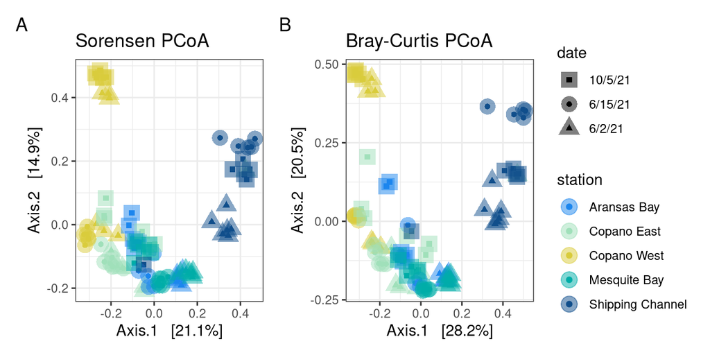

```r
# Plot it: Sorensen PCoA
sorensen_pcoa_plot <-
  plot_ordination(physeq = scaled_physeq,
                ordination = scaled_soren_pcoa,
                color = "station",
                shape = "date",
                title = "Sorensen PCoA") +
  scale_color_manual(values = station_colors) +
  scale_shape_manual(values = c(15, 16, 17)) +
  geom_point(size = 5, alpha = 0.5, aes(color = station)) +
  theme_bw() +
  theme(legend.position = "right")


### Bray-Curtis
# Second, calculate PCoA with Bray-Curtis
scaled_bray_pcoa <-
  ordinate(physeq = scaled_physeq,
         method = "PCoA",
         distance = "bray", binary = FALSE)

# Plot it: Bray-Curtis PCoA
bray_pcoa_plot <-
  plot_ordination(physeq = scaled_physeq,
                ordination = scaled_bray_pcoa,
                color = "station",
                shape = "date",
                title = "Bray-Curtis PCoA") +
  scale_color_manual(values = station_colors) +
  scale_shape_manual(values = c(15, 16, 17)) +
  geom_point(size = 5, alpha = 0.5, aes(color = station)) +
  theme_bw() +
  theme(legend.position = "right")

# Show the plots
sorensen_pcoa_plot + bray_pcoa_plot +
  plot_layout(guides = "collect") +
  plot_annotation(tag_levels = "A")
```

Above are two PCoA (Principal Coordinates Analysis) plots showing differences in microbial community composition across sampling stations and dates:

- **Left (Panel A):** Sorensen dissimilarity (presence/absence-based)
- **Right (Panel B):** Bray-Curtis dissimilarity (abundance-weighted)

We can conclude that:

1. Station is the dominant factor structuring microbial communities.
2. Date also contributes, likely reflecting environmental or seasonal change.
3. Bray-Curtis highlights both spatial and temporal patterns more strongly because between the two axes more variation is explained (~50%) than Sorensen (~35%), suggesting that abundance differences among taxa matter in this system. We gain ~15% of more variation explained in the data in 2 axes when incorporating abundances.

INTERPRETATION #8: Plot your data using a PCoA. Interpret what you can conclude from the PCoA.

## 6b. NMDS: Non-Metric Multidimensional Scaling

**Non-metric Multidimensional Scaling (NMDS)** is a rank-based ordination method commonly used in microbial ecology to visualize differences in community composition. Unlike metric methods like PCoA, *NMDS does not preserve exact distances but instead maintains the rank order of dissimilarities between samples*. This makes it well-suited for ecological data that are high-dimensional, non-linear, and zero-inflated.

NMDS works by iteratively arranging samples in a low-dimensional space (typically 2D) to best match the original distance rankings from a dissimilarity matrix, such as Bray-Curtis. The quality of the fit is measured by stress—lower stress indicates a better match. Because NMDS does not assume linear relationships and is less prone to artifacts like the arch effect, it is ideal for exploring patterns in complex microbial datasets. Interpretation focuses on the relative positioning of samples rather than axis variance, making it especially useful for identifying ecological gradients or clustering by treatment or site.

In NMDS, the **stress value** is a key metric that quantifies how well the lower-dimensional ordination preserves the rank order of distances from the original high-dimensional dissimilarity matrix. In simple terms, stress reflects how faithfully the 2D or 3D plot represents the real structure of your microbial community data. The lower the stress, the better the ordination represents the data.

- **Stress < 0.1** is often reported as a strong result.
- **Stress < 0.2** is still commonly accepted but it’s best if < 0.15, especially with complex, high-diversity microbiome data (*e.g.,* 16S or metagenomic datasets with many samples and ASVs).
- Some papers explicitly state they use NMDS for visualizing trends, not exact distances, so stress < 0.2 is considered acceptable in that context.
- It’s common to see NMDS with stress values between 0.08–0.15 in published studies.

*Okay, let’s draw some NMDS plots!*

```r
## SORENSEN
scaled_soren_nmds <-
  ordinate(physeq = scaled_physeq,
         method = "NMDS",
         distance = "bray", binary = TRUE)
```

```
## Square root transformation
## Wisconsin double standardization
## *** Best solution was not repeated -- monoMDS stopping criteria:
##     18: stress ratio > sratmax
##      2: scale factor of the gradient < sfgrmin
```

```r
# Plot it!
sorensen_nmds_plot <-
  plot_ordination(physeq = scaled_physeq,
                ordination = scaled_soren_nmds,
                color = "station",
                shape = "date",
                title = "Sorensen NMDS") +
  scale_color_manual(values = station_colors) +
  scale_shape_manual(values = c(15, 16, 17)) +
  geom_point(size = 5, alpha = 0.5, aes(color = station)) +
  theme_bw() +
  theme(legend.position = "right")

### Bray-Curtis
# Second, calculate NMDS with Bray-Curtis
scaled_bray_nmds <-
  ordinate(physeq = scaled_physeq,
         method = "NMDS",
         distance = "bray", binary = FALSE)
```

```
## Square root transformation
## Wisconsin double standardization
## *** Best solution was not repeated -- monoMDS stopping criteria:
##      1: no. of iterations >= maxit
##     19: stress ratio > sratmax
```

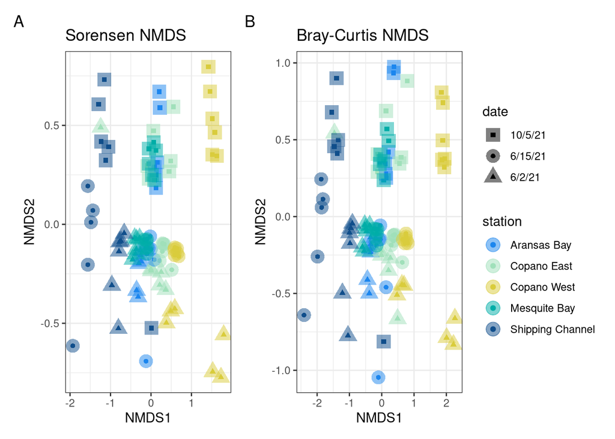

```r
# Plot it: Bray-Curtis NMDS
bray_nmds_plot <-
  plot_ordination(physeq = scaled_physeq,
                ordination = scaled_bray_nmds,
                color = "station",
                shape = "date",
                title = "Bray-Curtis NMDS") +
  scale_color_manual(values = station_colors) +
  scale_shape_manual(values = c(15, 16, 17)) +
  geom_point(size = 5, alpha = 0.5, aes(color = station)) +
  theme_bw() +
  theme(legend.position = "right")

# Show the plots
sorensen_nmds_plot + bray_nmds_plot +
  plot_layout(guides = "collect") +
  plot_annotation(tag_levels = "A")
```

INTERPRETATION #9: Plot your data using NMDS. Interpret what you can conclude from the NMDS.

## All ordinations together!

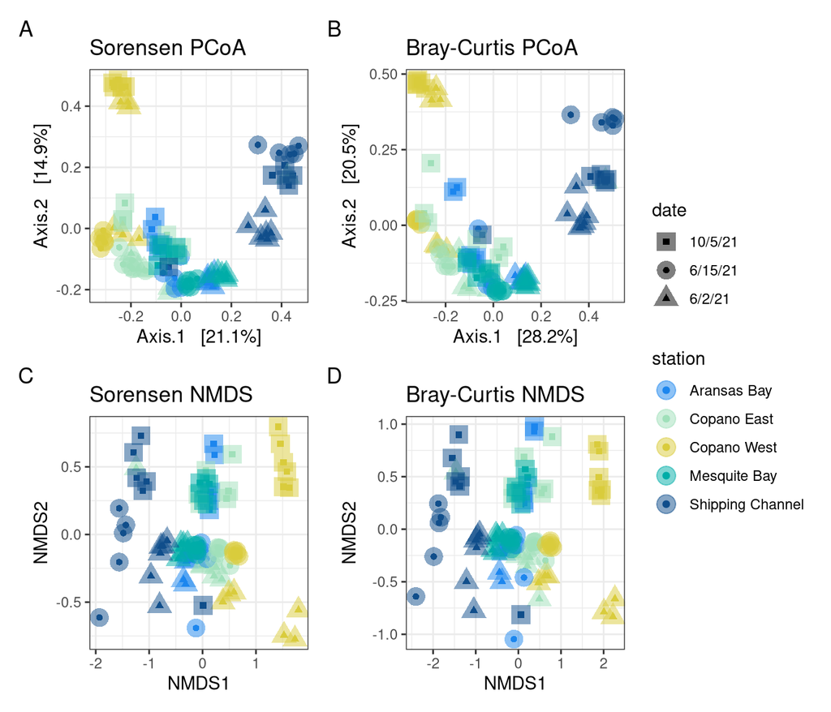

```r
sorensen_pcoa_plot + bray_pcoa_plot +
sorensen_nmds_plot + bray_nmds_plot +
  plot_layout(guides = "collect") +
  plot_annotation(tag_levels = "A")
```

INTERPRETATION #10: Plot both the PCoA and NMDS together. Which of the two visualizations work best for your data? Explain your reasoning.

# Now what?

Based on the results above, which metric would you use to write up your paper: Sorensen or Bray-Curtis?

# Final info for Reproducibility

## Check Render Time

```r
# Take the time now that we are at the end of the script
end_time <- Sys.time()
end_time
```

```
## [1] "2025-04-17 09:50:07 EDT"
```

```r
# Echo the elapsed time
elapsed_time <- round((end_time - start_time), 3)
elapsed_time
```

```
## Time difference of 27.926 secs
```